# sims presentation

Dom Owens

29/09/2020

We set up simulations to investigate how the following aspects affect the performance of the procedure

- Bandwidth
- Dimensionality
- The size of parameter changes
- Lengths of stationary segments
- Sample size in the subsample scheme

For each setting, we report

- `Size` The empirical size under null
- `Power` empirical power under alternative
- `Average #CPs` mean number of change points detected under alternative
- `SD of #CPs` standard deviation of number of change points detected under alternative
- `Location estimate 1` average number of times the first change was located (within +- 40)
- `Location estimate 2` average number of times the second change was located (within +- 40)

(Currently not all simulations have size reported - this is a next step)

## Bandwidth

```
$n=2000$, varying $G = 50, 100, 200, 400$, $d=5, p=1$, $N=1000$ iterations

changes at $k_1=750$ and $k_2=1500$
```

```r
dfBandwidth <- t(data.frame(reportVec(BandwidthWald50),reportVec(BandwidthWald100),reportVec(BandwidthWald200),reportVec(BandwidthWald400)))
colnames(dfBandwidth) <- names
BandwidthSize <- c(mean(BandwidthWaldNull50[,1]),mean(BandwidthWaldNull100[,1]),mean(BandwidthWaldNull200[,1]),
                      mean(BandwidthWaldNull400[,1]))
cbind(Size = BandwidthSize, dfBandwidth)
```

```
##                              Size Power Average #CPs SD of #CPs
## reportVec.BandwidthWald50.  0.944     1        4.464  0.8164966
## reportVec.BandwidthWald100. 0.027     1        1.473  0.5000000
## reportVec.BandwidthWald200. 0.000     1        1.707  0.5000000
## reportVec.BandwidthWald400. 0.000     1        1.508  0.5000000
##                             Location estimate 1 Location estimate 2
## reportVec.BandwidthWald50.                0.538               1.004
## reportVec.BandwidthWald100.               0.353               1.000
## reportVec.BandwidthWald200.               0.646               1.000
## reportVec.BandwidthWald400.               0.467               1.000
```

With respect to increasing bandwidths, size decreases to 0, power is close to 1 (always, in this setting), location performance peaks at $G=200$.

The following is one sample path with $G=200$ - the first change is less detectable than the second

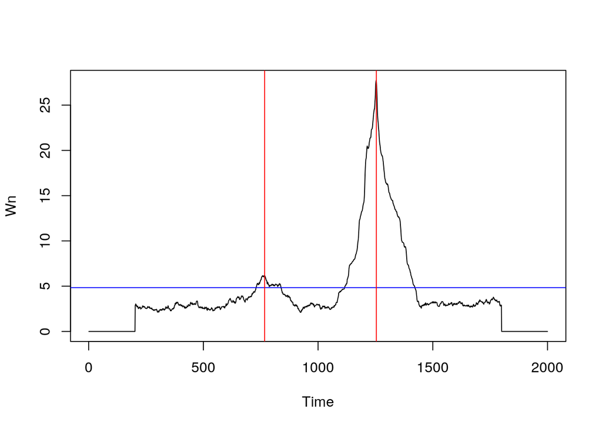

```r
#sB200 <- simBandwidth(iterations = 1,G=200, test = "Wald")
sB200Plot
```

## Dimensionality

```
How does dimensionality affect power/size?


$n=2000$, $d=1,2,3,4,$ $p=2$, $norm(A_{j+1}-A_{j}) = a$, $N=1000$ iterations

changes at $k_1=750$ and $k_2=1500$
```

*THIS CURRENTLY DOESN’T WORK AS INTENDED - will revise*

```r
dfDim <- t(data.frame(reportVec(DimensionWald1),reportVec(DimensionWald2),reportVec(DimensionWald3),reportVec(DimensionWald4)))
colnames(dfDim) <- names
dfDim
```

```
##                           Power Average #CPs SD of #CPs Location estimate 1
## reportVec.DimensionWald1. 0.000        0.000          0               0.000
## reportVec.DimensionWald2. 0.000        0.000          0               0.000
## reportVec.DimensionWald3. 0.000        0.000          0               0.000
## reportVec.DimensionWald4. 0.008        0.008          0               0.002
##                           Location estimate 2
## reportVec.DimensionWald1.               0.000
## reportVec.DimensionWald2.               0.000
## reportVec.DimensionWald3.               0.000
## reportVec.DimensionWald4.               0.006
```

```r
#simDimension(pars2, 2,iterations = 1,G=200, test = "Wald")
```

## Change Size

```
How does magnitude of parameter change affect p/s?

$n=2000$, $d=5, p=1$, varying size of changes   i.e. $norm(A_{j+1}-A_{j})$ = a, 2a, 4a, 8a, $N=1000$ iterations

changes at $k_1=750$ and $k_2=1500$
```

```r
dfSize <- t(data.frame(reportVec(SizeWald1),reportVec(SizeWald2),reportVec(SizeWald3),reportVec(SizeWald4)))
colnames(dfSize) <- names
dfSize
```

```
##                      Power Average #CPs SD of #CPs Location estimate 1
## reportVec.SizeWald1. 0.124        0.133  0.0000000               0.050
## reportVec.SizeWald2. 0.728        0.793  0.5000000               0.622
## reportVec.SizeWald3. 0.996        1.241  0.5773503               0.951
## reportVec.SizeWald4. 1.000        1.773  0.5000000               0.988
##                      Location estimate 2
## reportVec.SizeWald1.               0.003
## reportVec.SizeWald2.               0.013
## reportVec.SizeWald3.               0.186
## reportVec.SizeWald4.               0.718
```

With respect to increasing change sizes, power increases to 1, location performance increases notably

The following are two sample paths, the second with a change 4 times the size of the first change

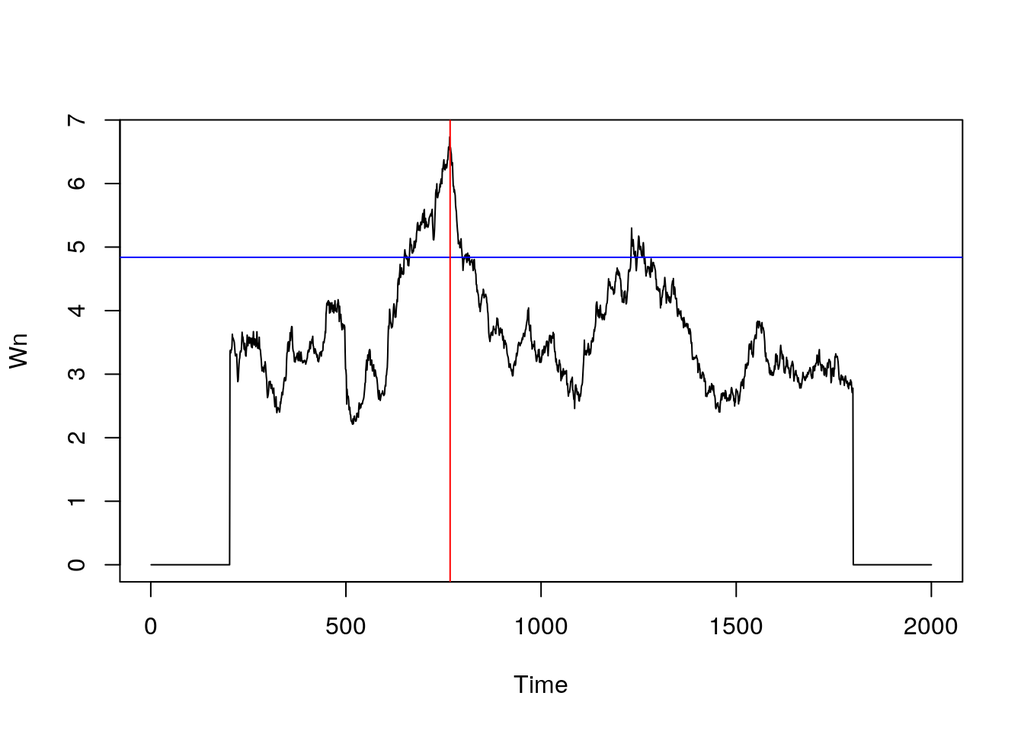

```r
#sS2<-simSize(PARS2, iterations = 1,G=200, test = "Wald")
sS2Plot
```

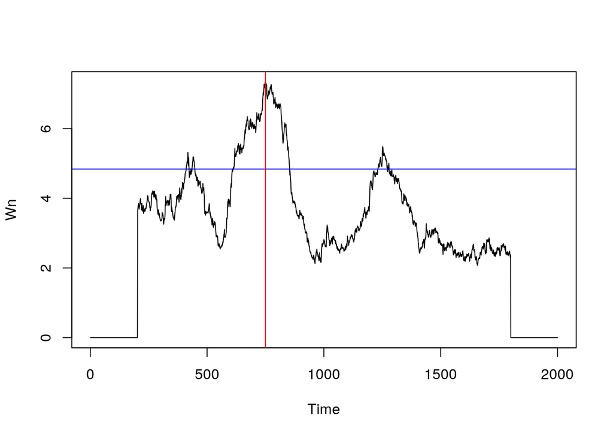

```r
#sS4<-simSize(PARS4, iterations = 1,G=200, test = "Wald")
sS4Plot
```

## Segment Length

```
How does diff in gap between changes affect p/s?

- multiscale example:   G set = $(50, 100, 200, 400)$

gap $= 50, 100, 200, 400$
```

```r
dfSegment <- t(data.frame(reportVec(SizeSegment1),reportVec(SizeSegment2),reportVec(SizeSegment3),reportVec(SizeSegment4)))
colnames(dfSegment) <- names
dfSegment
```

```
##                         Power Average #CPs SD of #CPs Location estimate 1
## reportVec.SizeSegment1.     1            0        0.5                   0
## reportVec.SizeSegment2.     1            0        0.5                   0
## reportVec.SizeSegment3.     1            0        0.5                   0
## reportVec.SizeSegment4.     1            0        0.5                   0
##                         Location estimate 2
## reportVec.SizeSegment1.                   0
## reportVec.SizeSegment2.                   0
## reportVec.SizeSegment3.                   0
## reportVec.SizeSegment4.                   0
```

*ALSO NOT WORKING*

## Sample Length

```
How does varying n affect p/s in subsample scheme?

- subsample example: d=5 p=1, $G=n^{2/3}$, n=2000, 5000, 10000, 20000

changes at $k_1 =  floor(n/3)$ and $k_2 = floor(2n/3)$
```

First we use the Wald method

```r
dfLength <- t(data.frame(reportVec(Length1),reportVec(Length2),reportVec(Length3),reportVec(Length4)))
colnames(dfLength) <- names
dfLength
```

```
##                    Power Average #CPs SD of #CPs Location estimate 1
## reportVec.Length1. 0.393        0.417  0.0000000               0.181
## reportVec.Length2. 0.350        0.405  0.9574271               0.140
## reportVec.Length3. 0.874        1.161  0.8164966               0.764
## reportVec.Length4. 0.935        1.402  0.8164966               0.865
##                    Location estimate 2
## reportVec.Length1.               0.005
## reportVec.Length2.               0.001
## reportVec.Length3.               0.003
## reportVec.Length4.               0.033
```

The following are two sample paths, one with $n=2000$, the other with $n=10000$

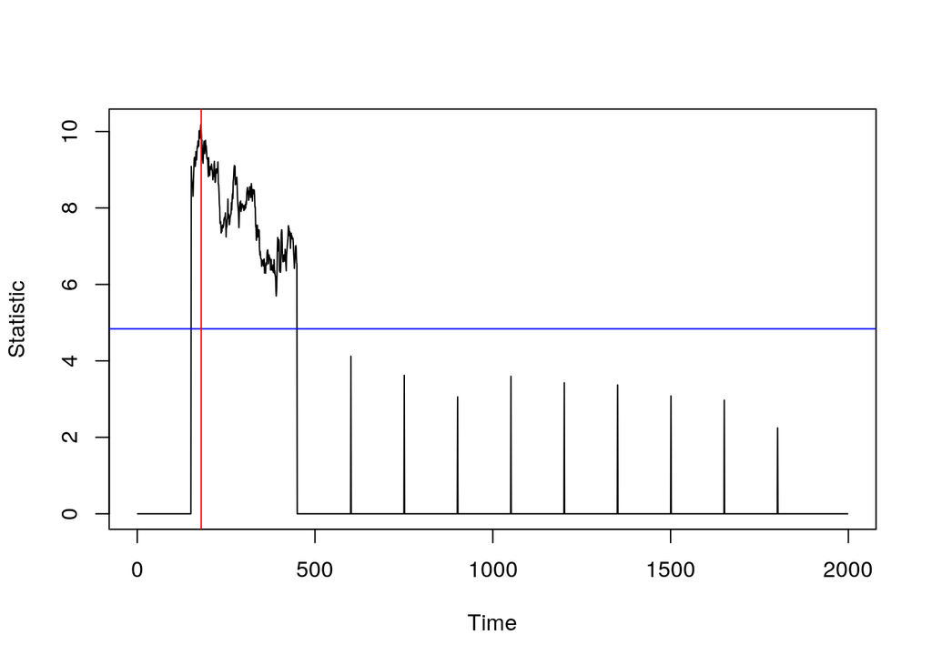

```r
#sL2000<-simLength(2000, PARS2, iterations = 1, test = "Wald")
sL2000Plot
```

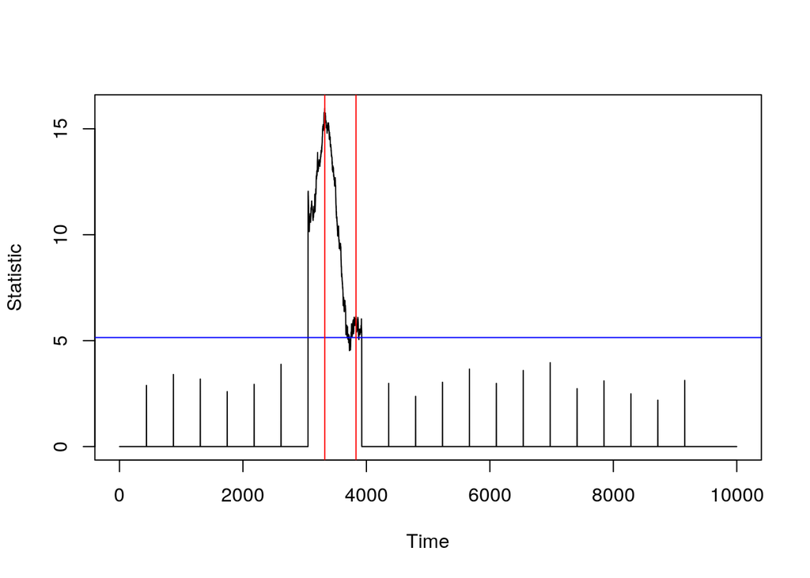

```r
#sL10000<-simLength(10000, PARS2, iterations = 1, test = "Wald")
sL10000Plot
```

Now we use the Score method

```r
dfLengthScore <- t(data.frame(reportVec(Length1Score),reportVec(Length2Score),reportVec(Length3Score)))
colnames(dfLengthScore) <- names
dfLengthScore
```

```
##                         Power Average #CPs SD of #CPs Location estimate 1
## reportVec.Length1Score.     1        3.186  0.5773503               0.150
## reportVec.Length2Score.     1        5.808  2.2173558               0.515
## reportVec.Length3Score.     1        8.548  3.0000000               0.837
##                         Location estimate 2
## reportVec.Length1Score.               0.256
## reportVec.Length2Score.               0.531
## reportVec.Length3Score.               0.641
```

This overestimates the number of change points. Are we setting $G$ too small proportionally to $n$?

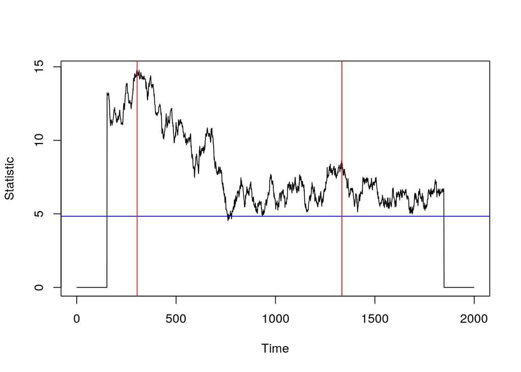

```r
#sLS2000<-simLength(2000, PARS2, iterations = 1, method = "Score")
sLS2000Plot
```

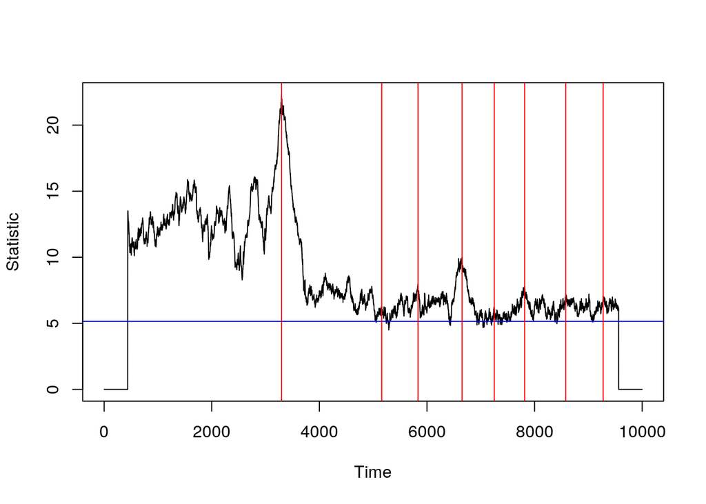

```r
#sLS10000<-simLength(10000, PARS2, iterations = 1, method = "Score")
sLS10000Plot
```